# Week 5 Homework: Perception & Principles

Author

Affiliation

Yasmeen R’ghioui

George Washington University

Published

February 19, 2026

# Week 5 — Perception & Principles

- I started off by finding a website that had graphs of bad data visualizations. I found a bad pie chart off of the website listed below.

```python
from IPython.display import display, Markdown

url = "https://www.jotform.com/blog/bad-data-visualization/"
link_text = "Bad Data Visualizations Website"

display(Markdown(f"[{link_text}]({url})"))
```

[Bad Data Visualizations Website](https://www.jotform.com/blog/bad-data-visualization/)

## 1) Environment Setup

```python
import numpy as np
import pandas as pd
import matplotlib.pyplot as plt
import seaborn as sns
import plotly.express as px
from sklearn.datasets import load_iris
data = pd.read_csv("Recreated_data.csv")
```

## 2) Example of Bad Data Visualization

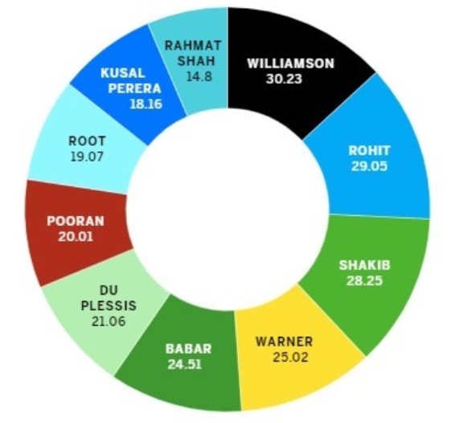

Example of a Bad Chart

- I got this chart from the bad data visualizations website. It seems to show players and some kind of score they received.

## 3) Recreated Pie Chart in Python

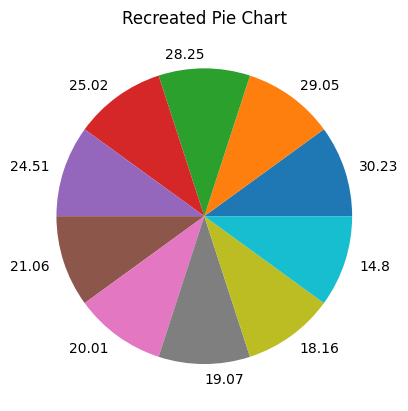

```python
nums = data['Values'].value_counts()

plt.pie(nums, labels=nums.index)
plt.title("Recreated Pie Chart")
plt.show()
```

- I recreated the original pie chart using Python. I first created a CSV and replicated the data from the original table. Then I uploaded the CSV into the data I could use here. It was hard for me to get the pie slices to be different sizes, so sorry about that. I also couldn’t put a hole in the middle like in the original chart.

## 4) Revised Data into Bar Chart

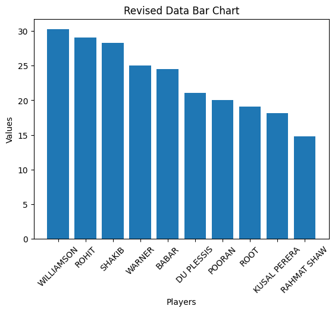

```python
plt.bar(data["Places"], data["Values"])
plt.title("Revised Data Bar Chart")
plt.xlabel('Players');plt.ylabel('Values')
plt.xticks(rotation=45)
plt.show()
```

- I recreated the data by using a bar chart. It is easier to read and distinguish the data values this way.

## 5) Reflection

- The original donut chart was visually appealing but misleading and ineffective. Although the slices were technically proportional to the values, the circular layout made it difficult to accurately compare players’ performances. The chart also didn’t add up to 100, as you would’ve expected it to. Human perception is not very precise at judging angles or arc lengths, especially when differences between values are small. For example, distinguishing between 28.25 and 29.05 or 24.51 and 25.02 requires careful inspection of the labels rather than visual interpretation. The heavy use of color and the central hole also added decorative elements that distracted from the data itself. As a result, viewers were forced to read each number individually instead of quickly understanding rankings or differences. My redesign was guided by principles of clarity, accuracy, and effective data comparison. I first recreated the visualization with Python and then used a bar chart because bar charts rely on aligned lengths along a common axis. This makes differences in magnitude much easier to interpret. I also focused on minimizing unnecessary visual elements and ensuring labels were clear and readable. The redesigned bar chart improves comprehension because viewers can instantly see which player has the highest and lowest values and compare differences more precisely. The linear scale allows for faster, more accurate visual judgments, making the data easier to understand at a glance.